# House Sales Price Prediction in King County

## The Data

We will be using data from a Kaggle data set:

https://www.kaggle.com/harlfoxem/housesalesprediction

#### Feature Columns

- id - Unique ID for each home sold
- date - Date of the home sale
- price - Price of each home sold
- bedrooms - Number of bedrooms
- bathrooms - Number of bathrooms, where .5 accounts for a room with a toilet but no shower
- sqft_living - Square footage of the apartments interior living space
- sqft_lot - Square footage of the land space
- floors - Number of floors
- waterfront - A dummy variable for whether the apartment was overlooking the waterfront or not
- view - An index from 0 to 4 of how good the view of the property was
- condition - An index from 1 to 5 on the condition of the apartment,
- grade - An index from 1 to 13, where 1-3 falls short of building construction and design, 7 has an average level of construction and design, and 11-13 have a high quality level of construction and design.
- sqft_above - The square footage of the interior housing space that is above ground level
- sqft_basement - The square footage of the interior housing space that is below ground level
- yr_built - The year the house was initially built
- yr_renovated - The year of the house’s last renovation
- zipcode - What zipcode area the house is in
- lat - Lattitude
- long - Longitude
- sqft_living15 - The square footage of interior housing living space for the nearest 15 neighbors
- sqft_lot15 - The square footage of the land lots of the nearest 15 neighbors

```python
import pandas as pd
import numpy as np
import matplotlib.pyplot as plt
import seaborn as sns
```

```python
from tensorflow.keras.models import Sequential
from tensorflow.keras.layers import BatchNormalization
from tensorflow.keras.layers import Dense, Activation
from tensorflow.keras.optimizers import Adam
```

```python
from sklearn.model_selection import train_test_split
from sklearn.preprocessing import MinMaxScaler
from sklearn.metrics import mean_absolute_error, mean_squared_error, explained_variance_score
```

```python
df = pd.read_csv('C:\\AI_Deep_Learning\\TF_2_Notebooks_and_Data\\DATA\\kc_house_data.csv')
```

# Exploratory Data Analysis

```python
df.isnull().sum()
```

```
id               0
date             0
price            0
bedrooms         0
bathrooms        0
sqft_living      0
sqft_lot         0
floors           0
waterfront       0
view             0
condition        0
grade            0
sqft_above       0
sqft_basement    0
yr_built         0
yr_renovated     0
zipcode          0
lat              0
long             0
sqft_living15    0
sqft_lot15       0
dtype: int64
```

```python
df.describe().transpose()
```

|  | count | mean | std | min | 25% | 50% | 75% | max |
| --- | --- | --- | --- | --- | --- | --- | --- | --- |
| id | 21597.0 | 4.580474e+09 | 2.876736e+09 | 1.000102e+06 | 2.123049e+09 | 3.904930e+09 | 7.308900e+09 | 9.900000e+09 |
| price | 21597.0 | 5.402966e+05 | 3.673681e+05 | 7.800000e+04 | 3.220000e+05 | 4.500000e+05 | 6.450000e+05 | 7.700000e+06 |
| bedrooms | 21597.0 | 3.373200e+00 | 9.262989e-01 | 1.000000e+00 | 3.000000e+00 | 3.000000e+00 | 4.000000e+00 | 3.300000e+01 |
| bathrooms | 21597.0 | 2.115826e+00 | 7.689843e-01 | 5.000000e-01 | 1.750000e+00 | 2.250000e+00 | 2.500000e+00 | 8.000000e+00 |
| sqft_living | 21597.0 | 2.080322e+03 | 9.181061e+02 | 3.700000e+02 | 1.430000e+03 | 1.910000e+03 | 2.550000e+03 | 1.354000e+04 |
| sqft_lot | 21597.0 | 1.509941e+04 | 4.141264e+04 | 5.200000e+02 | 5.040000e+03 | 7.618000e+03 | 1.068500e+04 | 1.651359e+06 |
| floors | 21597.0 | 1.494096e+00 | 5.396828e-01 | 1.000000e+00 | 1.000000e+00 | 1.500000e+00 | 2.000000e+00 | 3.500000e+00 |
| waterfront | 21597.0 | 7.547345e-03 | 8.654900e-02 | 0.000000e+00 | 0.000000e+00 | 0.000000e+00 | 0.000000e+00 | 1.000000e+00 |
| view | 21597.0 | 2.342918e-01 | 7.663898e-01 | 0.000000e+00 | 0.000000e+00 | 0.000000e+00 | 0.000000e+00 | 4.000000e+00 |
| condition | 21597.0 | 3.409825e+00 | 6.505456e-01 | 1.000000e+00 | 3.000000e+00 | 3.000000e+00 | 4.000000e+00 | 5.000000e+00 |
| grade | 21597.0 | 7.657915e+00 | 1.173200e+00 | 3.000000e+00 | 7.000000e+00 | 7.000000e+00 | 8.000000e+00 | 1.300000e+01 |
| sqft_above | 21597.0 | 1.788597e+03 | 8.277598e+02 | 3.700000e+02 | 1.190000e+03 | 1.560000e+03 | 2.210000e+03 | 9.410000e+03 |
| sqft_basement | 21597.0 | 2.917250e+02 | 4.426678e+02 | 0.000000e+00 | 0.000000e+00 | 0.000000e+00 | 5.600000e+02 | 4.820000e+03 |
| yr_built | 21597.0 | 1.971000e+03 | 2.937523e+01 | 1.900000e+03 | 1.951000e+03 | 1.975000e+03 | 1.997000e+03 | 2.015000e+03 |
| yr_renovated | 21597.0 | 8.446479e+01 | 4.018214e+02 | 0.000000e+00 | 0.000000e+00 | 0.000000e+00 | 0.000000e+00 | 2.015000e+03 |
| zipcode | 21597.0 | 9.807795e+04 | 5.351307e+01 | 9.800100e+04 | 9.803300e+04 | 9.806500e+04 | 9.811800e+04 | 9.819900e+04 |
| lat | 21597.0 | 4.756009e+01 | 1.385518e-01 | 4.715590e+01 | 4.747110e+01 | 4.757180e+01 | 4.767800e+01 | 4.777760e+01 |
| long | 21597.0 | -1.222140e+02 | 1.407235e-01 | -1.225190e+02 | -1.223280e+02 | -1.222310e+02 | -1.221250e+02 | -1.213150e+02 |
| sqft_living15 | 21597.0 | 1.986620e+03 | 6.852305e+02 | 3.990000e+02 | 1.490000e+03 | 1.840000e+03 | 2.360000e+03 | 6.210000e+03 |
| sqft_lot15 | 21597.0 | 1.275828e+04 | 2.727444e+04 | 6.510000e+02 | 5.100000e+03 | 7.620000e+03 | 1.008300e+04 | 8.712000e+05 |

```python
df.iloc[1]
```

```
id               6414100192
date              12/9/2014
price                538000
bedrooms                  3
bathrooms              2.25
sqft_living            2570
sqft_lot               7242
floors                    2
waterfront                0
view                      0
condition                 3
grade                     7
sqft_above             2170
sqft_basement           400
yr_built               1951
yr_renovated           1991
zipcode               98125
lat                  47.721
long               -122.319
sqft_living15          1690
sqft_lot15             7639
Name: 1, dtype: object
```

```python
df[1:2]
```

|  | id | date | price | bedrooms | bathrooms | sqft_living | sqft_lot | floors | waterfront | view | ... | grade | sqft_above | sqft_basement | yr_built | yr_renovated | zipcode | lat | long | sqft_living15 | sqft_lot15 |
| --- | --- | --- | --- | --- | --- | --- | --- | --- | --- | --- | --- | --- | --- | --- | --- | --- | --- | --- | --- | --- | --- |
| 1 | 6414100192 | 12/9/2014 | 538000.0 | 3 | 2.25 | 2570 | 7242 | 2.0 | 0 | 0 | ... | 7 | 2170 | 400 | 1951 | 1991 | 98125 | 47.721 | -122.319 | 1690 | 7639 |

1 rows × 21 columns

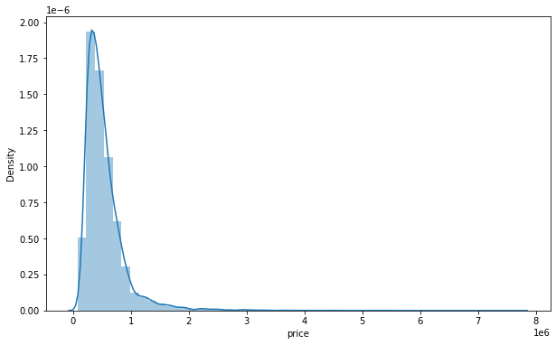

```python
plt.figure(figsize=(10,6))
sns.distplot(df['price'])
```

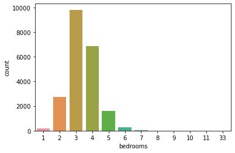

```python
sns.countplot(df['bedrooms'])
```

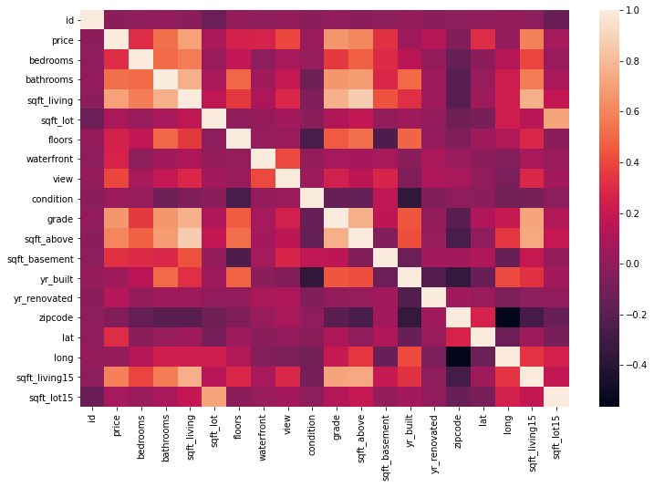

```python
plt.figure(figsize=(12,8))
sns.heatmap(df.corr())
```

```python
priceDf = pd.DataFrame(df.corr()['price'])
priceDf.drop(index='price',inplace = True)
priceDf.sort_values(by = 'price',ascending=False, inplace = True)
priceDf.reset_index(inplace = True)
priceDf
```

|  | index | price |
| --- | --- | --- |
| 0 | sqft_living | 0.701917 |
| 1 | grade | 0.667951 |
| 2 | sqft_above | 0.605368 |
| 3 | sqft_living15 | 0.585241 |
| 4 | bathrooms | 0.525906 |
| 5 | view | 0.397370 |
| 6 | sqft_basement | 0.323799 |
| 7 | bedrooms | 0.308787 |
| 8 | lat | 0.306692 |
| 9 | waterfront | 0.266398 |
| 10 | floors | 0.256804 |
| 11 | yr_renovated | 0.126424 |
| 12 | sqft_lot | 0.089876 |
| 13 | sqft_lot15 | 0.082845 |
| 14 | yr_built | 0.053953 |
| 15 | condition | 0.036056 |
| 16 | long | 0.022036 |
| 17 | id | -0.016772 |
| 18 | zipcode | -0.053402 |

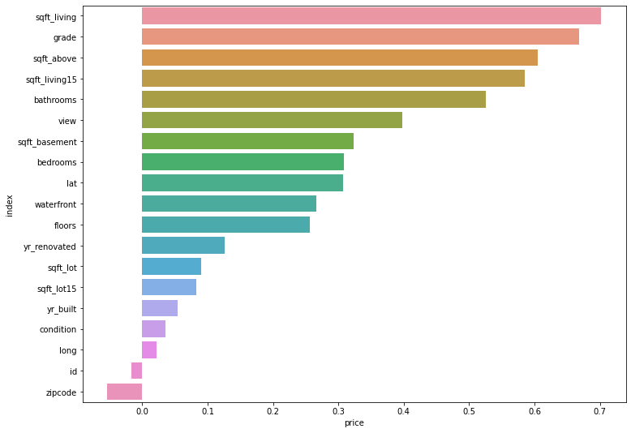

```python
plt.figure(figsize=(12,9))
sns.barplot(x = 'price',y = 'index', data = priceDf)
```

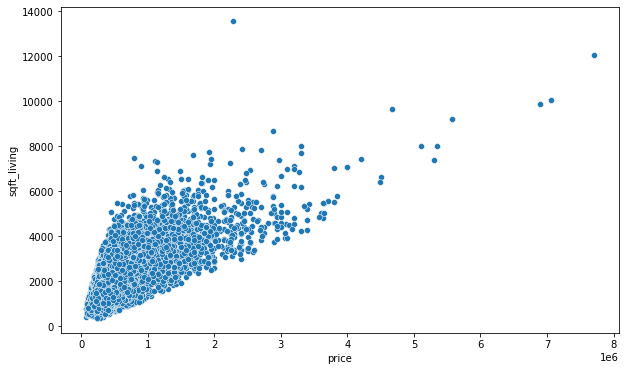

```python
plt.figure(figsize=(10,6))
sns.scatterplot(x='price',y='sqft_living',data=df)
```

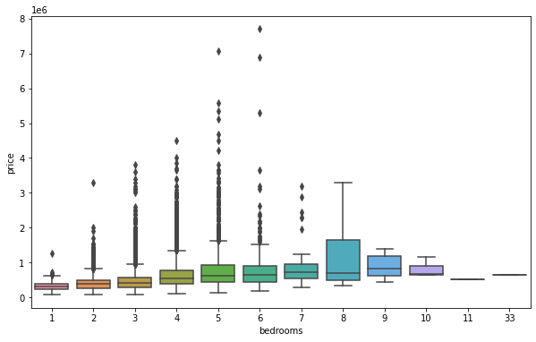

```python
plt.figure(figsize=(10,6))
sns.boxplot(x='bedrooms',y='price',data=df)
```

### Geographical Properties

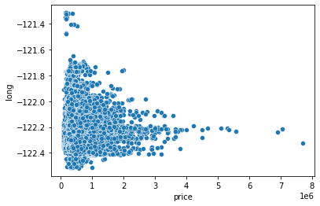

```python
sns.scatterplot(x='price',y='long',data=df)
```

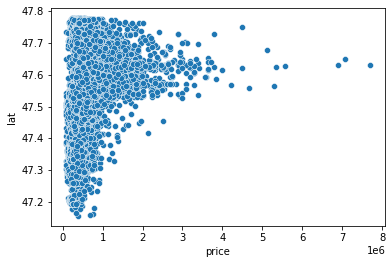

```python
sns.scatterplot(x='price',y='lat',data=df)
```

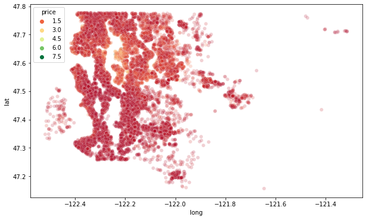

```python
plt.figure(figsize=(10,6))
sns.scatterplot(x='long',y='lat',
                data=df,hue='price',
                palette='RdYlGn',alpha=0.2)
```

```python
df.sort_values('price',ascending=False).head(20)
```

|  | id | date | price | bedrooms | bathrooms | sqft_living | sqft_lot | floors | waterfront | view | ... | grade | sqft_above | sqft_basement | yr_built | yr_renovated | zipcode | lat | long | sqft_living15 | sqft_lot15 |
| --- | --- | --- | --- | --- | --- | --- | --- | --- | --- | --- | --- | --- | --- | --- | --- | --- | --- | --- | --- | --- | --- |
| 7245 | 6762700020 | 10/13/2014 | 7700000.0 | 6 | 8.00 | 12050 | 27600 | 2.5 | 0 | 3 | ... | 13 | 8570 | 3480 | 1910 | 1987 | 98102 | 47.6298 | -122.323 | 3940 | 8800 |
| 3910 | 9808700762 | 6/11/2014 | 7060000.0 | 5 | 4.50 | 10040 | 37325 | 2.0 | 1 | 2 | ... | 11 | 7680 | 2360 | 1940 | 2001 | 98004 | 47.6500 | -122.214 | 3930 | 25449 |
| 9245 | 9208900037 | 9/19/2014 | 6890000.0 | 6 | 7.75 | 9890 | 31374 | 2.0 | 0 | 4 | ... | 13 | 8860 | 1030 | 2001 | 0 | 98039 | 47.6305 | -122.240 | 4540 | 42730 |
| 4407 | 2470100110 | 8/4/2014 | 5570000.0 | 5 | 5.75 | 9200 | 35069 | 2.0 | 0 | 0 | ... | 13 | 6200 | 3000 | 2001 | 0 | 98039 | 47.6289 | -122.233 | 3560 | 24345 |
| 1446 | 8907500070 | 4/13/2015 | 5350000.0 | 5 | 5.00 | 8000 | 23985 | 2.0 | 0 | 4 | ... | 12 | 6720 | 1280 | 2009 | 0 | 98004 | 47.6232 | -122.220 | 4600 | 21750 |
| 1313 | 7558700030 | 4/13/2015 | 5300000.0 | 6 | 6.00 | 7390 | 24829 | 2.0 | 1 | 4 | ... | 12 | 5000 | 2390 | 1991 | 0 | 98040 | 47.5631 | -122.210 | 4320 | 24619 |
| 1162 | 1247600105 | 10/20/2014 | 5110000.0 | 5 | 5.25 | 8010 | 45517 | 2.0 | 1 | 4 | ... | 12 | 5990 | 2020 | 1999 | 0 | 98033 | 47.6767 | -122.211 | 3430 | 26788 |
| 8085 | 1924059029 | 6/17/2014 | 4670000.0 | 5 | 6.75 | 9640 | 13068 | 1.0 | 1 | 4 | ... | 12 | 4820 | 4820 | 1983 | 2009 | 98040 | 47.5570 | -122.210 | 3270 | 10454 |
| 2624 | 7738500731 | 8/15/2014 | 4500000.0 | 5 | 5.50 | 6640 | 40014 | 2.0 | 1 | 4 | ... | 12 | 6350 | 290 | 2004 | 0 | 98155 | 47.7493 | -122.280 | 3030 | 23408 |
| 8629 | 3835500195 | 6/18/2014 | 4490000.0 | 4 | 3.00 | 6430 | 27517 | 2.0 | 0 | 0 | ... | 12 | 6430 | 0 | 2001 | 0 | 98004 | 47.6208 | -122.219 | 3720 | 14592 |
| 12358 | 6065300370 | 5/6/2015 | 4210000.0 | 5 | 6.00 | 7440 | 21540 | 2.0 | 0 | 0 | ... | 12 | 5550 | 1890 | 2003 | 0 | 98006 | 47.5692 | -122.189 | 4740 | 19329 |
| 4145 | 6447300265 | 10/14/2014 | 4000000.0 | 4 | 5.50 | 7080 | 16573 | 2.0 | 0 | 0 | ... | 12 | 5760 | 1320 | 2008 | 0 | 98039 | 47.6151 | -122.224 | 3140 | 15996 |
| 2083 | 8106100105 | 11/14/2014 | 3850000.0 | 4 | 4.25 | 5770 | 21300 | 2.0 | 1 | 4 | ... | 11 | 5770 | 0 | 1980 | 0 | 98040 | 47.5850 | -122.222 | 4620 | 22748 |
| 7028 | 853200010 | 7/1/2014 | 3800000.0 | 5 | 5.50 | 7050 | 42840 | 1.0 | 0 | 2 | ... | 13 | 4320 | 2730 | 1978 | 0 | 98004 | 47.6229 | -122.220 | 5070 | 20570 |
| 19002 | 2303900100 | 9/11/2014 | 3800000.0 | 3 | 4.25 | 5510 | 35000 | 2.0 | 0 | 4 | ... | 13 | 4910 | 600 | 1997 | 0 | 98177 | 47.7296 | -122.370 | 3430 | 45302 |
| 16288 | 7397300170 | 5/30/2014 | 3710000.0 | 4 | 3.50 | 5550 | 28078 | 2.0 | 0 | 2 | ... | 12 | 3350 | 2200 | 2000 | 0 | 98039 | 47.6395 | -122.234 | 2980 | 19602 |
| 18467 | 4389201095 | 5/11/2015 | 3650000.0 | 5 | 3.75 | 5020 | 8694 | 2.0 | 0 | 1 | ... | 12 | 3970 | 1050 | 2007 | 0 | 98004 | 47.6146 | -122.213 | 4190 | 11275 |
| 6502 | 4217402115 | 4/21/2015 | 3650000.0 | 6 | 4.75 | 5480 | 19401 | 1.5 | 1 | 4 | ... | 11 | 3910 | 1570 | 1936 | 0 | 98105 | 47.6515 | -122.277 | 3510 | 15810 |
| 15241 | 2425049063 | 9/11/2014 | 3640000.0 | 4 | 3.25 | 4830 | 22257 | 2.0 | 1 | 4 | ... | 11 | 4830 | 0 | 1990 | 0 | 98039 | 47.6409 | -122.241 | 3820 | 25582 |
| 19133 | 3625049042 | 10/11/2014 | 3640000.0 | 5 | 6.00 | 5490 | 19897 | 2.0 | 0 | 0 | ... | 12 | 5490 | 0 | 2005 | 0 | 98039 | 47.6165 | -122.236 | 2910 | 17600 |

20 rows × 21 columns

```python
len(df)*(0.01)
```

```
215.97
```

```python
non_top_1_perc = df.sort_values('price',ascending=False).iloc[216:]
```

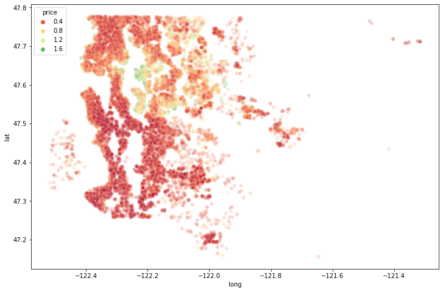

```python
plt.figure(figsize=(12,8))
sns.scatterplot(x='long',y='lat',
                data=non_top_1_perc,hue='price',
                palette='RdYlGn',alpha=0.2)
```

### Other Features

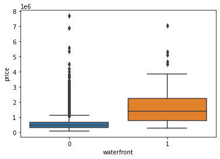

```python
sns.boxplot(x='waterfront',y='price',data=df)
```

## Working with Feature Data

```python
df.head()
```

|  | id | date | price | bedrooms | bathrooms | sqft_living | sqft_lot | floors | waterfront | view | ... | grade | sqft_above | sqft_basement | yr_built | yr_renovated | zipcode | lat | long | sqft_living15 | sqft_lot15 |
| --- | --- | --- | --- | --- | --- | --- | --- | --- | --- | --- | --- | --- | --- | --- | --- | --- | --- | --- | --- | --- | --- |
| 0 | 7129300520 | 10/13/2014 | 221900.0 | 3 | 1.00 | 1180 | 5650 | 1.0 | 0 | 0 | ... | 7 | 1180 | 0 | 1955 | 0 | 98178 | 47.5112 | -122.257 | 1340 | 5650 |
| 1 | 6414100192 | 12/9/2014 | 538000.0 | 3 | 2.25 | 2570 | 7242 | 2.0 | 0 | 0 | ... | 7 | 2170 | 400 | 1951 | 1991 | 98125 | 47.7210 | -122.319 | 1690 | 7639 |
| 2 | 5631500400 | 2/25/2015 | 180000.0 | 2 | 1.00 | 770 | 10000 | 1.0 | 0 | 0 | ... | 6 | 770 | 0 | 1933 | 0 | 98028 | 47.7379 | -122.233 | 2720 | 8062 |
| 3 | 2487200875 | 12/9/2014 | 604000.0 | 4 | 3.00 | 1960 | 5000 | 1.0 | 0 | 0 | ... | 7 | 1050 | 910 | 1965 | 0 | 98136 | 47.5208 | -122.393 | 1360 | 5000 |
| 4 | 1954400510 | 2/18/2015 | 510000.0 | 3 | 2.00 | 1680 | 8080 | 1.0 | 0 | 0 | ... | 8 | 1680 | 0 | 1987 | 0 | 98074 | 47.6168 | -122.045 | 1800 | 7503 |

5 rows × 21 columns

```python
df.info()
```

```
<class 'pandas.core.frame.DataFrame'>
RangeIndex: 21597 entries, 0 to 21596
Data columns (total 21 columns):
 #   Column         Non-Null Count  Dtype
---  ------         --------------  -----
 0   id             21597 non-null  int64
 1   date           21597 non-null  object
 2   price          21597 non-null  float64
 3   bedrooms       21597 non-null  int64
 4   bathrooms      21597 non-null  float64
 5   sqft_living    21597 non-null  int64
 6   sqft_lot       21597 non-null  int64
 7   floors         21597 non-null  float64
 8   waterfront     21597 non-null  int64
 9   view           21597 non-null  int64
 10  condition      21597 non-null  int64
 11  grade          21597 non-null  int64
 12  sqft_above     21597 non-null  int64
 13  sqft_basement  21597 non-null  int64
 14  yr_built       21597 non-null  int64
 15  yr_renovated   21597 non-null  int64
 16  zipcode        21597 non-null  int64
 17  lat            21597 non-null  float64
 18  long           21597 non-null  float64
 19  sqft_living15  21597 non-null  int64
 20  sqft_lot15     21597 non-null  int64
dtypes: float64(5), int64(15), object(1)
memory usage: 3.5+ MB
```

```python
df = df.drop('id',axis=1)
```

```python
df.head(2)
```

|  | date | price | bedrooms | bathrooms | sqft_living | sqft_lot | floors | waterfront | view | condition | grade | sqft_above | sqft_basement | yr_built | yr_renovated | zipcode | lat | long | sqft_living15 | sqft_lot15 |
| --- | --- | --- | --- | --- | --- | --- | --- | --- | --- | --- | --- | --- | --- | --- | --- | --- | --- | --- | --- | --- |
| 0 | 10/13/2014 | 221900.0 | 3 | 1.00 | 1180 | 5650 | 1.0 | 0 | 0 | 3 | 7 | 1180 | 0 | 1955 | 0 | 98178 | 47.5112 | -122.257 | 1340 | 5650 |
| 1 | 12/9/2014 | 538000.0 | 3 | 2.25 | 2570 | 7242 | 2.0 | 0 | 0 | 3 | 7 | 2170 | 400 | 1951 | 1991 | 98125 | 47.7210 | -122.319 | 1690 | 7639 |

### Feature Engineering from Date

```python
df['date'] = pd.to_datetime(df['date'])
```

```python
df.head(2)
```

|  | date | price | bedrooms | bathrooms | sqft_living | sqft_lot | floors | waterfront | view | condition | grade | sqft_above | sqft_basement | yr_built | yr_renovated | zipcode | lat | long | sqft_living15 | sqft_lot15 |
| --- | --- | --- | --- | --- | --- | --- | --- | --- | --- | --- | --- | --- | --- | --- | --- | --- | --- | --- | --- | --- |
| 0 | 2014-10-13 | 221900.0 | 3 | 1.00 | 1180 | 5650 | 1.0 | 0 | 0 | 3 | 7 | 1180 | 0 | 1955 | 0 | 98178 | 47.5112 | -122.257 | 1340 | 5650 |
| 1 | 2014-12-09 | 538000.0 | 3 | 2.25 | 2570 | 7242 | 2.0 | 0 | 0 | 3 | 7 | 2170 | 400 | 1951 | 1991 | 98125 | 47.7210 | -122.319 | 1690 | 7639 |

```python
df['month'] = df['date'].apply(lambda date:date.month)
```

```python
df['year'] = df['date'].apply(lambda date:date.year)
```

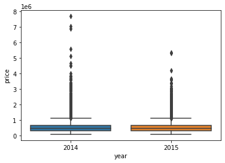

```python
sns.boxplot(x='year',y='price',data=df)
```

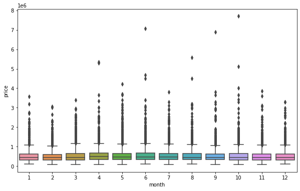

```python
plt.figure(figsize=(10,6))
sns.boxplot(x='month',y='price',data=df)
```

```python
df.groupby('month').mean()['price']
```

```
month
1     525963.251534
2     508520.051323
3     544057.683200
4     562215.615074
5     550849.746893
6     557534.318182
7     544892.161013
8     536655.212481
9     529723.517787
10    539439.447228
11    522359.903478
12    524799.902041
Name: price, dtype: float64
```

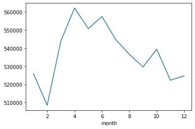

```python
df.groupby('month').mean()['price'].plot()
```

```python
df.groupby('year').mean()['price']
```

```
year
2014    539350.911777
2015    542279.005878
Name: price, dtype: float64
```

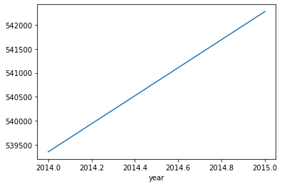

```python
df.groupby('year').mean()['price'].plot()
```

```python
df = df.drop('date',axis=1)
```

```python
df.columns
```

```
Index(['price', 'bedrooms', 'bathrooms', 'sqft_living', 'sqft_lot', 'floors',
       'waterfront', 'view', 'condition', 'grade', 'sqft_above',
       'sqft_basement', 'yr_built', 'yr_renovated', 'zipcode', 'lat', 'long',
       'sqft_living15', 'sqft_lot15', 'month', 'year'],
      dtype='object')
```

```python
df['waterfront'].value_counts()
```

```
0    21434
1      163
Name: waterfront, dtype: int64
```

```python
df['zipcode'].value_counts()
```

```
98103    602
98038    589
98115    583
98052    574
98117    553
        ...
98102    104
98010    100
98024     80
98148     57
98039     50
Name: zipcode, Length: 70, dtype: int64
```

```python
df = df.drop('zipcode',axis=1)
```

```python
df.head()
```

|  | price | bedrooms | bathrooms | sqft_living | sqft_lot | floors | waterfront | view | condition | grade | sqft_above | sqft_basement | yr_built | yr_renovated | lat | long | sqft_living15 | sqft_lot15 | month | year |
| --- | --- | --- | --- | --- | --- | --- | --- | --- | --- | --- | --- | --- | --- | --- | --- | --- | --- | --- | --- | --- |
| 0 | 221900.0 | 3 | 1.00 | 1180 | 5650 | 1.0 | 0 | 0 | 3 | 7 | 1180 | 0 | 1955 | 0 | 47.5112 | -122.257 | 1340 | 5650 | 10 | 2014 |
| 1 | 538000.0 | 3 | 2.25 | 2570 | 7242 | 2.0 | 0 | 0 | 3 | 7 | 2170 | 400 | 1951 | 1991 | 47.7210 | -122.319 | 1690 | 7639 | 12 | 2014 |
| 2 | 180000.0 | 2 | 1.00 | 770 | 10000 | 1.0 | 0 | 0 | 3 | 6 | 770 | 0 | 1933 | 0 | 47.7379 | -122.233 | 2720 | 8062 | 2 | 2015 |
| 3 | 604000.0 | 4 | 3.00 | 1960 | 5000 | 1.0 | 0 | 0 | 5 | 7 | 1050 | 910 | 1965 | 0 | 47.5208 | -122.393 | 1360 | 5000 | 12 | 2014 |
| 4 | 510000.0 | 3 | 2.00 | 1680 | 8080 | 1.0 | 0 | 0 | 3 | 8 | 1680 | 0 | 1987 | 0 | 47.6168 | -122.045 | 1800 | 7503 | 2 | 2015 |

```python
# could make sense due to scaling, higher should correlate to more value
df['yr_renovated'].value_counts()
```

```
0       20683
2014       91
2013       37
2003       36
2000       35
        ...
1934        1
1959        1
1951        1
1948        1
1944        1
Name: yr_renovated, Length: 70, dtype: int64
```

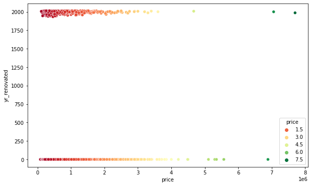

```python
plt.figure(figsize=(10,6))
sns.scatterplot(x='price',y='yr_renovated',
                data=df,hue='price',
                palette='RdYlGn')
plt.show()
```

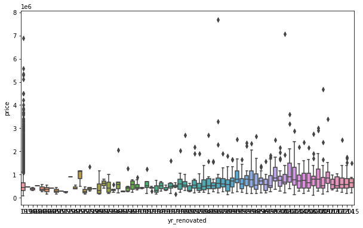

```python
plt.figure(figsize=(10,6))
sns.boxplot(x='yr_renovated',y='price',data=df)
```

```python
df.groupby('yr_renovated').mean()['price']
```

```
yr_renovated
0       530559.899193
1934    459950.000000
1940    378400.000000
1944    521000.000000
1945    398666.666667
            ...
2011    607496.153846
2012    625181.818182
2013    664960.810811
2014    655030.098901
2015    659156.250000
Name: price, Length: 70, dtype: float64
```

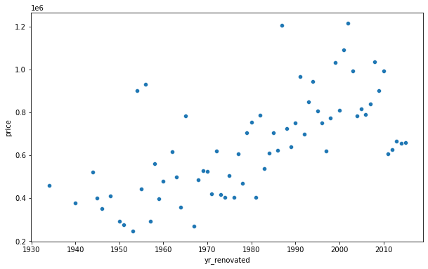

```python
plt.figure(figsize=(10,6))
sns.scatterplot(data =df.groupby('yr_renovated').mean()['price'][1:])
```

```python
df['sqft_basement'].value_counts()
```

```
0       13110
600       221
700       218
500       214
800       206
        ...
792         1
2590        1
935         1
2390        1
248         1
Name: sqft_basement, Length: 306, dtype: int64
```

```python
df.groupby('sqft_basement').mean()['price']
```

```
sqft_basement
0       4.870689e+05
10      1.919000e+05
20      4.850000e+05
40      4.004250e+05
50      4.773580e+05
            ...
3260    1.900000e+06
3480    7.700000e+06
3500    3.200000e+06
4130    2.280000e+06
4820    4.670000e+06
Name: price, Length: 306, dtype: float64
```

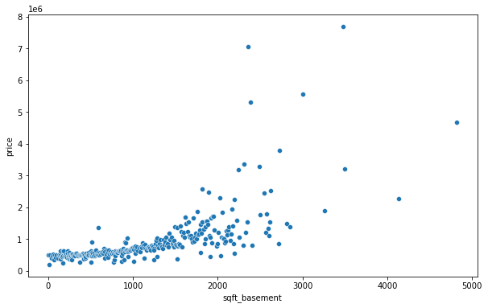

```python
plt.figure(figsize=(10,6))
sns.scatterplot(data =df.groupby('sqft_basement').mean()['price'])
```

```python
df.head()
```

|  | price | bedrooms | bathrooms | sqft_living | sqft_lot | floors | waterfront | view | condition | grade | sqft_above | sqft_basement | yr_built | yr_renovated | lat | long | sqft_living15 | sqft_lot15 | month | year |
| --- | --- | --- | --- | --- | --- | --- | --- | --- | --- | --- | --- | --- | --- | --- | --- | --- | --- | --- | --- | --- |
| 0 | 221900.0 | 3 | 1.00 | 1180 | 5650 | 1.0 | 0 | 0 | 3 | 7 | 1180 | 0 | 1955 | 0 | 47.5112 | -122.257 | 1340 | 5650 | 10 | 2014 |
| 1 | 538000.0 | 3 | 2.25 | 2570 | 7242 | 2.0 | 0 | 0 | 3 | 7 | 2170 | 400 | 1951 | 1991 | 47.7210 | -122.319 | 1690 | 7639 | 12 | 2014 |
| 2 | 180000.0 | 2 | 1.00 | 770 | 10000 | 1.0 | 0 | 0 | 3 | 6 | 770 | 0 | 1933 | 0 | 47.7379 | -122.233 | 2720 | 8062 | 2 | 2015 |
| 3 | 604000.0 | 4 | 3.00 | 1960 | 5000 | 1.0 | 0 | 0 | 5 | 7 | 1050 | 910 | 1965 | 0 | 47.5208 | -122.393 | 1360 | 5000 | 12 | 2014 |
| 4 | 510000.0 | 3 | 2.00 | 1680 | 8080 | 1.0 | 0 | 0 | 3 | 8 | 1680 | 0 | 1987 | 0 | 47.6168 | -122.045 | 1800 | 7503 | 2 | 2015 |

```python
len(df.columns)
```

```
20
```

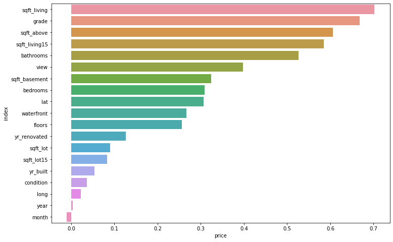

```python
plt.figure(figsize=(12,8))
priceDf2 = pd.DataFrame(df.corr()['price'])
priceDf2.drop(index='price',inplace = True)
priceDf2.sort_values(by = 'price',ascending=False, inplace = True)
priceDf2.reset_index(inplace = True)
sns.barplot(x = 'price',y = 'index', data = priceDf2)
```

## Scaling and Train Test Split

```python
X = df.drop('price',axis=1)
y = df['price']
```

```python
X_train, X_test, y_train, y_test = train_test_split(X,y,test_size=0.3,random_state=101)
```

### Scaling

```python
scaler = MinMaxScaler()
```

```python
X_train= scaler.fit_transform(X_train)
```

```python
X_test = scaler.transform(X_test)
```

```python
X_train.shape
```

```
(15117, 19)
```

```python
X_test.shape
```

```
(6480, 19)
```

```python
print(X_train.shape)
print(X_test.shape)
print(y_train.shape)
print(y_test.shape)

print (type((X_train)))
print(type((X_test)))
print(type((y_train)))
print(type((y_test)))
```

```
(15117, 19)
(6480, 19)
(15117,)
(6480,)
<class 'numpy.ndarray'>
<class 'numpy.ndarray'>
<class 'pandas.core.series.Series'>
<class 'pandas.core.series.Series'>
```

```python
y_train = y_train.values
y_test = y_test.values
print(X_train.shape)
print(X_test.shape)
print(y_train.shape)
print(y_test.shape)

print (type((X_train)))
print(type((X_test)))
print(type((y_train)))
print(type((y_test)))
```

```
(15117, 19)
(6480, 19)
(15117,)
(6480,)
<class 'numpy.ndarray'>
<class 'numpy.ndarray'>
<class 'numpy.ndarray'>
<class 'numpy.ndarray'>
```

## Creating a Model

```python
adam = Adam(learning_rate=0.1)
```

```python
model = Sequential()

model.add(Dense(19,activation='relu'))
model.add(Dense(19,activation='relu'))
model.add(Dense(19,activation='relu'))
model.add(Dense(19,activation='relu'))
model.add(Dense(1))

model.compile(optimizer=adam,loss='mse')
```

```
WARNING:tensorflow:From C:\Users\chait\Anaconda3\lib\site-packages\tensorflow\python\ops\init_ops.py:1251: calling VarianceScaling.__init__ (from tensorflow.python.ops.init_ops) with dtype is deprecated and will be removed in a future version.
Instructions for updating:
Call initializer instance with the dtype argument instead of passing it to the constructor
```

## Training the Model

```python
model.fit(x=X_train,y=y_train,
          validation_data=(X_test,y_test),
          batch_size=128,epochs=4000)
```

```
Train on 15117 samples, validate on 6480 samples
```

```
<tensorflow.python.keras.callbacks.History at 0x2169604e308>
```

```python
losses = pd.DataFrame(model.history.history)
```

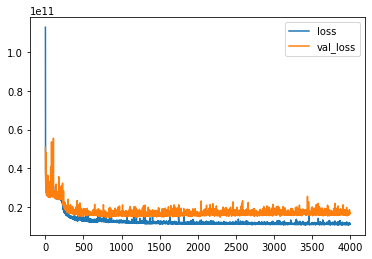

```python
losses.plot()
```

# Evaluation on Test Data

https://scikit-learn.org/stable/modules/model_evaluation.html#regression-metrics

#### Predicting on Brand New Data

```python
X_test
```

```
array([[0.1       , 0.08      , 0.04239917, ..., 0.00887725, 0.63636364,
        0.        ],
       [0.3       , 0.36      , 0.17269907, ..., 0.00993734, 0.81818182,
        0.        ],
       [0.2       , 0.24      , 0.12512927, ..., 0.00547073, 0.90909091,
        0.        ],
       ...,
       [0.1       , 0.08      , 0.05584281, ..., 0.00506255, 1.        ,
        0.        ],
       [0.3       , 0.2       , 0.22233713, ..., 0.00774485, 0.09090909,
        1.        ],
       [0.3       , 0.32      , 0.27611169, ..., 0.0196531 , 0.45454545,
        0.        ]])
```

```python
predictions = model.predict(X_test)
```

```python
mean_absolute_error(y_test,predictions)
```

```
72582.83024570794
```

```python
np.sqrt(mean_squared_error(y_test,predictions))
```

```
130316.99391933181
```

```python
mean_squared_error(y_test,predictions)
```

```
16982518904.171165
```

```python
df['price'].mean()
```

```
540296.5735055795
```

```python
df['price'].median()
```

```
450000.0
```

```python
explained_variance_score(y_test,predictions)
```

```
0.8741450529405818
```

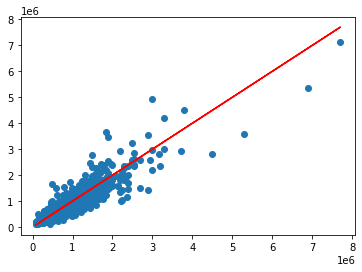

```python
# Our predictions
plt.scatter(y_test,predictions)

# Perfect predictions
plt.plot(y_test,y_test,'r')
```

```python
errors = y_test.reshape(6480, 1) - predictions
```

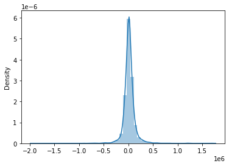

```python
sns.distplot(errors)
```

### Predicting on a brand new house

```python
single_house = df.drop('price',axis=1).iloc[0]
```

```python
single_house = scaler.transform(single_house.values.reshape(-1, 19))
```

```python
single_house
```

```
array([[0.2       , 0.08      , 0.08376422, 0.00310751, 0.        ,
        0.        , 0.        , 0.5       , 0.4       , 0.10785619,
        0.        , 0.47826087, 0.        , 0.57149751, 0.21760797,
        0.16193426, 0.00582059, 0.81818182, 0.        ]])
```

```python
model.predict(single_house)
```

```
array([[237434.]], dtype=float32)
```

```python
df.iloc[0]
```

```
price            221900.0000
bedrooms              3.0000
bathrooms             1.0000
sqft_living        1180.0000
sqft_lot           5650.0000
floors                1.0000
waterfront            0.0000
view                  0.0000
condition             3.0000
grade                 7.0000
sqft_above         1180.0000
sqft_basement         0.0000
yr_built           1955.0000
yr_renovated          0.0000
lat                  47.5112
long               -122.2570
sqft_living15      1340.0000
sqft_lot15         5650.0000
month                10.0000
year               2014.0000
Name: 0, dtype: float64
```